# sherryx_OriginalHomeworkCode_04

### Identify and interpret the point estimate of the slope (𝛽1β1), as well as the outcome of the test associated with the hypotheses H0: 𝛽1β1 = 0; HA: 𝛽1β1 ≠ 0. Also, find a 90 percent CI for the slope (𝛽1β1) parameter.

```r
#Identify the slope, hypothesis test, and CI using the results of lm()
slope_lm <- coef(summary(lm))["Brain_Size_Species_Mean", "Estimate"]

#90 percent CI
ci_lm <- confint(lm, level = 0.90)["Brain_Size_Species_Mean", ]

slope_lm
```

```
## [1] 1.21799
```

```r
ci_lm
```

```
##      5 %     95 %
## 1.035571 1.400410
```

```r
#Identify the slope, hypothesis test, and CI using the results of lm_log
slope_lm_log <- coef(summary(lm_log))["log(Brain_Size_Species_Mean)", "Estimate"]

#90 percent CI
ci_lm_log <- confint(lm_log, level = 0.90)["log(Brain_Size_Species_Mean)", ]

slope_lm_log
```

```
## [1] 0.2341496
```

```r
ci_lm_log
```

```
##       5 %      95 %
## 0.2046396 0.2636595
```

### Using your model, add lines for the 90 percent confidence and prediction interval bands on the plot and add a legend to differentiate between the lines.

```r
# CHALLENGE: confused about this part, for the 90th ci and perdiction interval... dont know if i sequenced it correctly
kamilar_cooper_predict <- data.frame(Brain_Size_Species_Mean = seq(min(kamilar_cooper$Brain_Size_Species_Mean, na.rm = TRUE), max(kamilar_cooper$Brain_Size_Species_Mean, na.rm = TRUE), length.ou = 100))
```

```r
# Prediction the confidence intervals for new data means based on the data above
ci_predict <- predict(lm, newdata = kamilar_cooper_predict, interval = "confidence", level = 0.90)

ci_predict
```

```
##          fit      lwr      upr
## 1   250.9376 232.7302 269.1450
## 2   256.9616 239.3572 274.5660
## 3   262.9856 245.9577 280.0135
## 4   269.0096 252.5290 285.4902
## 5   275.0336 259.0680 290.9992
## 6   281.0576 265.5716 296.5437
## 7   287.0816 272.0363 302.1270
## 8   293.1056 278.4586 307.7527
## 9   299.1297 284.8349 313.4244
## 10  305.1537 291.1619 319.1454
## 11  311.1777 297.4363 324.9191
## 12  317.2017 303.6550 330.7483
## 13  323.2257 309.8158 336.6356
## 14  329.2497 315.9168 342.5826
```

[output cut: 86 more lines]

```r
# Prediction the prediction intervals for new data means based on the data above
pi_predict <- predict(lm, newdata = kamilar_cooper_predict, interval = "prediction", level = 0.90)

pi_predict
```

```
##          fit       lwr       upr
## 1   250.9376  99.19856  402.6766
## 2   256.9616 105.29374  408.6295
## 3   262.9856 111.38358  414.5876
## 4   269.0096 117.46808  420.5511
## 5   275.0336 123.54724  426.5200
## 6   281.0576 129.62104  432.4942
## 7   287.0816 135.68947  438.4738
## 8   293.1056 141.75255  444.4587
## 9   299.1297 147.81025  450.4491
## 10  305.1537 153.86258  456.4447
## 11  311.1777 159.90953  462.4458
## 12  317.2017 165.95111  468.4522
## 13  323.2257 171.98730  474.4641
## 14  329.2497 178.01811  480.4813
```

[output cut: 86 more lines]

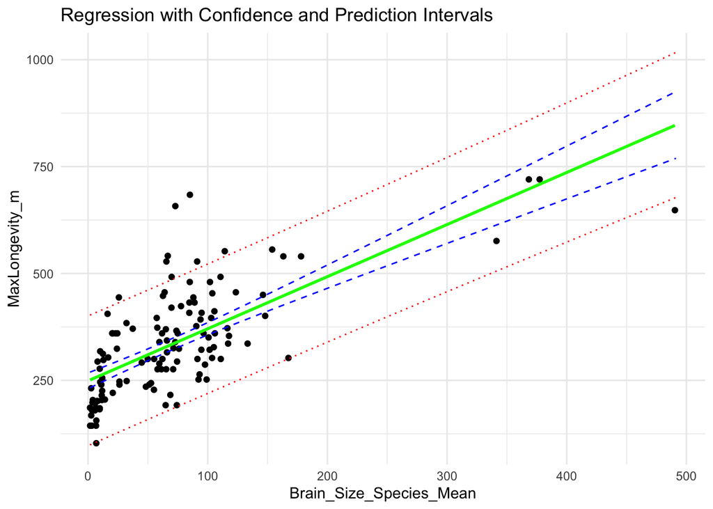

```r
# new prediction plot made based on the two plots above
# the difference here is that the 90 percent ci and pi (represented by the red and blue lines) are added in along with the initial linear model line (green line)
plot_predict <- ggplot(data = kamilar_cooper, aes(x = Brain_Size_Species_Mean, y = MaxLongevity_m)) +
  geom_point() +
  geom_smooth(method = "lm", formula = y ~ x, color = "green", se = FALSE) +
  geom_line(data = cbind(kamilar_cooper_predict, ci_predict), aes(y = lwr), color = "blue", linetype = "dashed") +
  geom_line(data = cbind(kamilar_cooper_predict, ci_predict), aes(y = upr), color = "blue", linetype = "dashed") +
  geom_line(data = cbind(kamilar_cooper_predict, pi_predict), aes(y = lwr), color = "red", linetype = "dotted") +
  geom_line(data = cbind(kamilar_cooper_predict, pi_predict), aes(y = upr), color = "red", linetype = "dotted") +
  ggtitle("Regression with Confidence and Prediction Intervals") +
  theme_minimal()

print(plot_predict)
```